# Norton Assignment 4

Jenny Norton

9/12/2020

## Question 1

Return to the iris data set included in R. Examine the distributions of Sepal.Length and Sepal.Width. Produce a graph (or two) which represent these distributions. What can you say about the variation of Sepal.Length and Sepal.Width?

```r
library(tidyverse)
str(iris)
```

```
## 'data.frame':    150 obs. of  5 variables:
##  $ Sepal.Length: num  5.1 4.9 4.7 4.6 5 5.4 4.6 5 4.4 4.9 ...
##  $ Sepal.Width : num  3.5 3 3.2 3.1 3.6 3.9 3.4 3.4 2.9 3.1 ...
##  $ Petal.Length: num  1.4 1.4 1.3 1.5 1.4 1.7 1.4 1.5 1.4 1.5 ...
##  $ Petal.Width : num  0.2 0.2 0.2 0.2 0.2 0.4 0.3 0.2 0.2 0.1 ...
##  $ Species     : Factor w/ 3 levels "setosa","versicolor",..: 1 1 1 1 1 1 1 1 1 1 ...
```

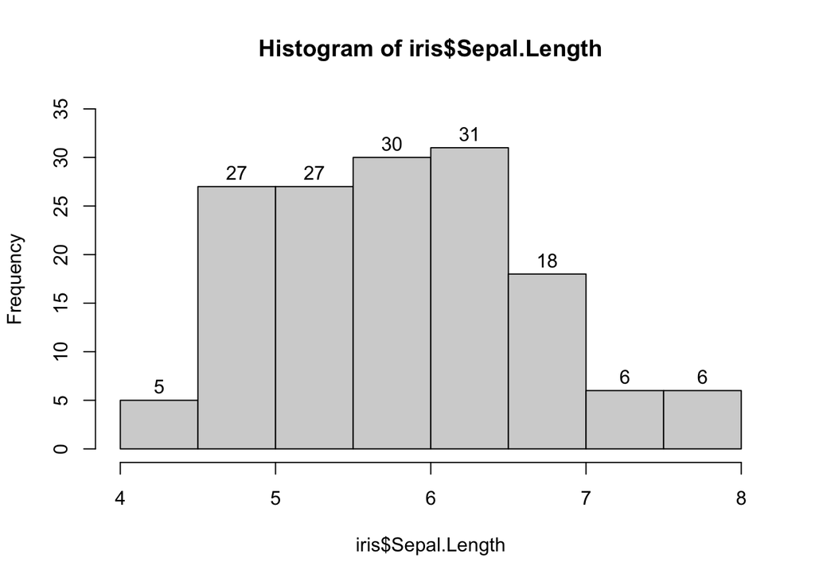

```r
hist(iris$Sepal.Length,
     labels = TRUE,
     ylim = c(0,35))
```

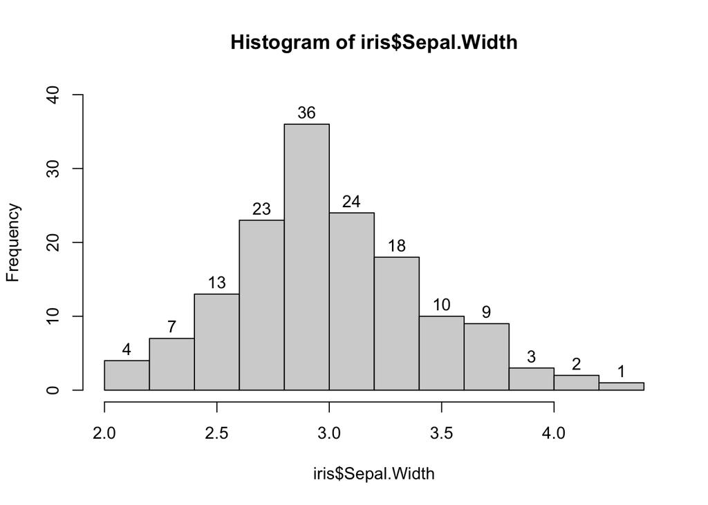

```r
hist(iris$Sepal.Width,
     labels = TRUE,
     ylim = c(0,40))
```

*Comments:*  
* A histogram is a reasonable choice, although I notice you don’t seem to have tried adjusting the bin sizes. Also, you need to fix the documentation on the graph (particularly x-axis and main title labels) to be something more readable/informative.

## Question 2

Examine how the categorical variable Species affects the distribution of Sepal.Length and Sepal.Width. Produce a graph (or two) which shows clearly the relationship you would like to demonstrate. Can the covariation here help explain some of the patterns we saw in first exploration?

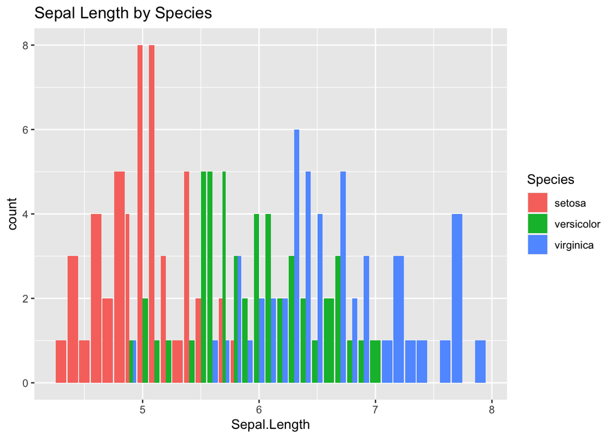

```r
iris %>%
  #group_by(Species) %>%
  ggplot() +
    geom_bar(aes(x = Sepal.Length, fill = Species), position = "dodge") +
    labs(title = "Sepal Length by Species")
```

*Comments:*  
* The group_by command here is not actually doing anything; I’ve commented it out to demonstrate (above). * A bar plot is not really appropriate here–that would be for discrete data rather than continuous. A histogram would work well, but I’d recommend separating the plots, like so:

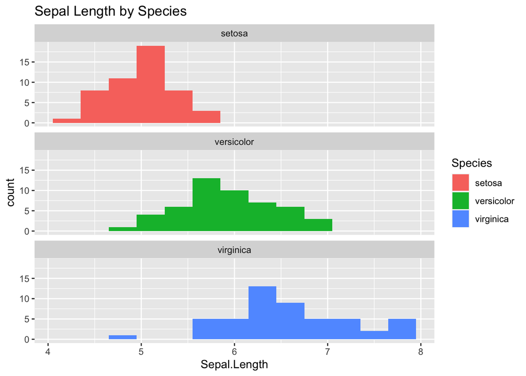

```r
iris %>%
  ggplot() +
    geom_histogram(aes(x = Sepal.Length, fill = Species), binwidth=.3) +
    facet_wrap( ~ Species, nrow = 3) +
    labs(title = "Sepal Length by Species")
```

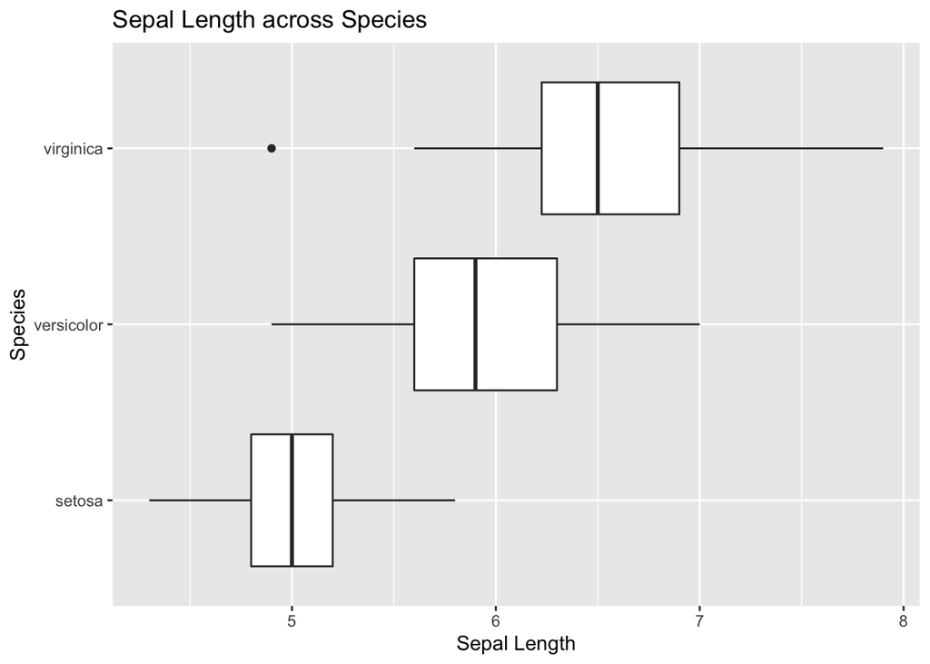

```r
ggplot(data = iris) +
  geom_boxplot(aes(x = Sepal.Length, y = Species)) +
                 labs(title = "Sepal Length across Species",
       x = "Sepal Length",
       y = "Species")
```

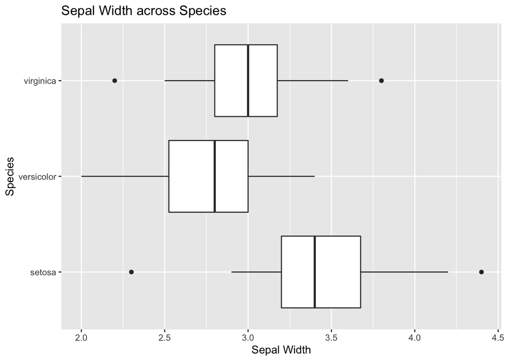

```r
ggplot(data = iris) +
  geom_boxplot(aes(x = Sepal.Width, y = Species)) +
                 labs(title = "Sepal Width across Species",
       x = "Sepal Width",
       y = "Species")
```

*Comments:*  
* Box plots are a really *good* choice for comparing distributions across different groups.

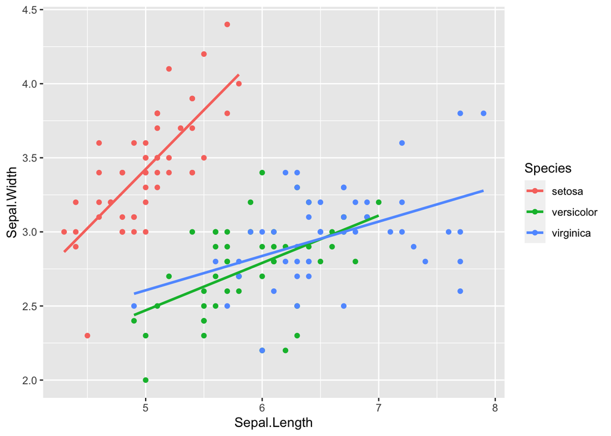

```r
ggplot(data = iris,
       aes(x = Sepal.Length,
           y = Sepal.Width,
           color = Species
           )
          ) +
  geom_point() +
  geom_smooth(method = "lm", se = FALSE, formula = y~x)
```

*Comments:*  
* But this plot does not really show information about the distributions of sepal width and length–this actually shows information about the *covariation* of these two variables.

The longer Sepal Length gets, the wider Sepal Width is. The species Setosa seems to get wider faster in comparison to the other two species.

*Comments:*  
* You have two good graphs (and some questionable ones), but don’t really answer how the distribution varies by species.

## Question 3

Examine the distribution of Sepal.Width now for data in only the species virginica in the data set. What can you say about the distribution?

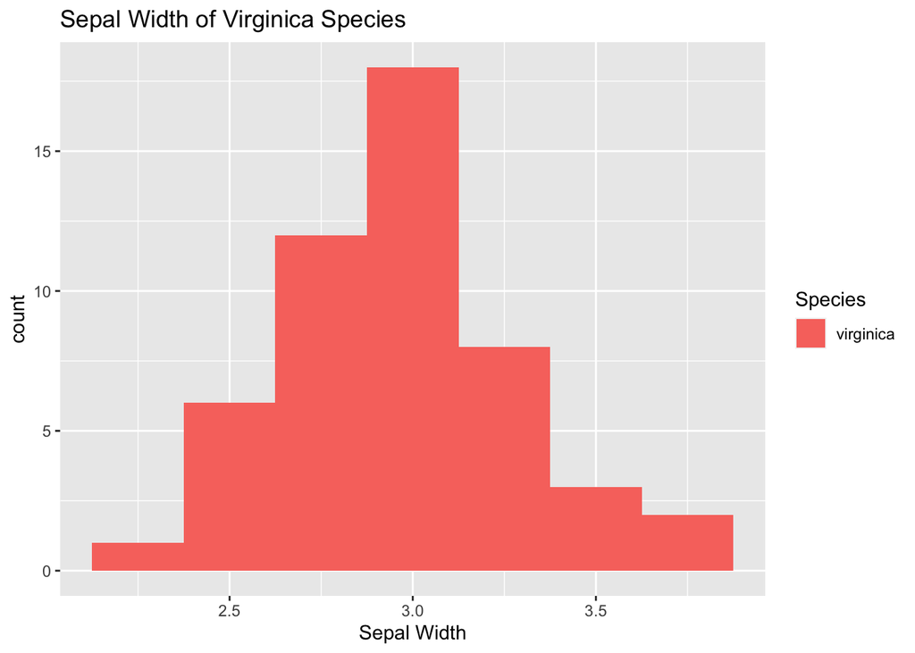

```r
iris %>%
  filter(Species == "virginica") %>%
  ggplot() +
  geom_histogram(aes(x = Sepal.Width, fill = Species),
        binwidth = .25) +
  labs(title = "Sepal Width of Virginica Species",
       x = "Sepal Width")
```

*Comments:*  
* Nice graph!